# Model v10_4 - simulation

Odin Rumianowski

2024-03-22

The results of the v10_4 model analysis of data simulated with the following computational parameters:

ni <- 65000; nb <- 15000; nc <- 3; nt <- 70; na <- 4000

### Apparent survival probability

The values used in the simulations are represented by the dotted red line and are :

phi1 = 0.213 - First year

phiA = 0.78 - Subadult and adult

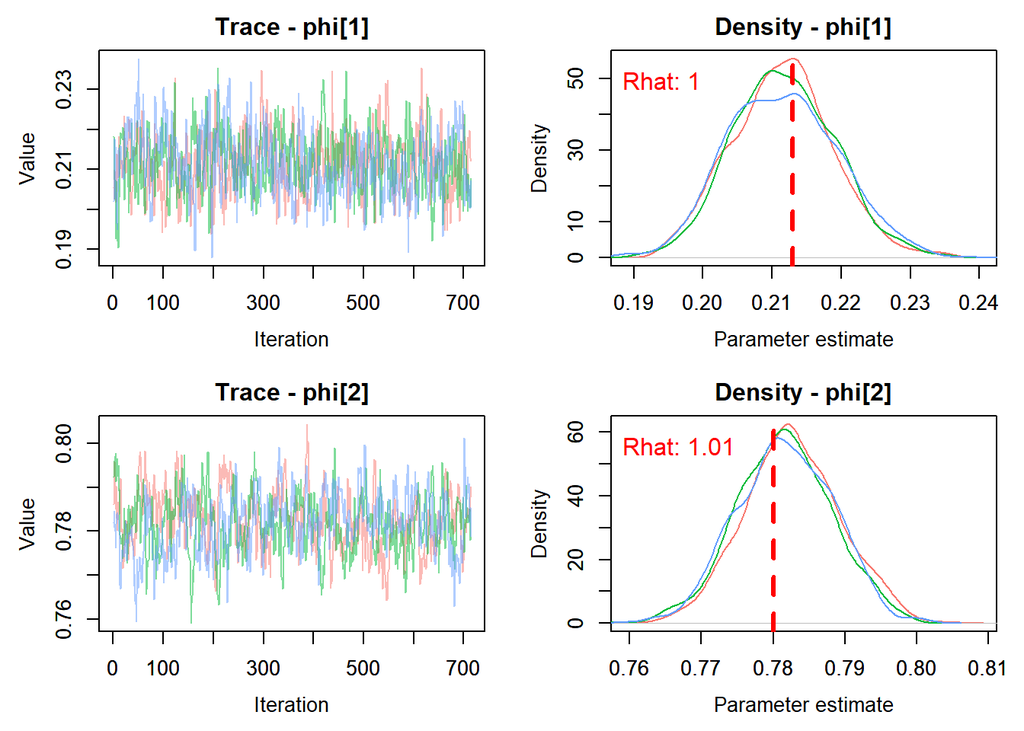

### Productivity

The values used in the simulations are represented by the dotted red line and are :

rhoLR = 1.732 - La Ronze

rhoSAT = 0.605 - Satellite colonies

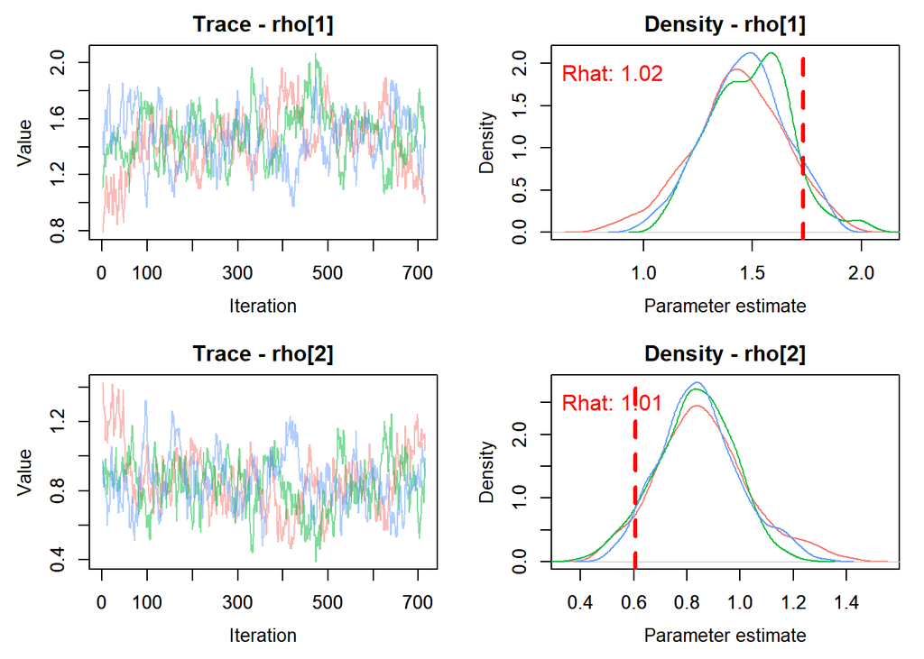

### Recruitment probability

The values used in the simulations are represented by the dotted red line and are :

kappaLR = 0.619 - La Ronze

kappaSAT = 0.846 - Satellite colonies

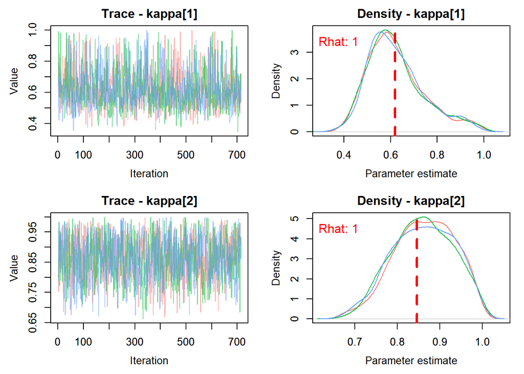

### Natal dispersion “eta” from one colony to another - colony dependence

In the dataset

| 0.3 | 0.05 | 0.2 | 0.05 | 0.40 |
| --- | --- | --- | --- | --- |
| 0.2 | 0.20 | 0.5 | 0.05 | 0.05 |
| 0.1 | 0.10 | 0.3 | 0.20 | 0.30 |
| 0.1 | 0.10 | 0.1 | 0.30 | 0.40 |
| 0.1 | 0.05 | 0.3 | 0.05 | 0.50 |

In the analysis

| 0.3413874 | 0.0464359 | 0.1897003 | 0.0343332 | 0.3881433 |
| --- | --- | --- | --- | --- |
| 0.2125099 | 0.2168511 | 0.4551635 | 0.0527766 | 0.0626990 |
| 0.1670403 | 0.0985585 | 0.3005230 | 0.1931239 | 0.2407543 |
| 0.0462421 | 0.1189703 | 0.0694404 | 0.3279763 | 0.4373709 |
| 0.1897414 | 0.2151508 | 0.1989595 | 0.2243563 | 0.1717919 |

### Breeding dispersion “nu” from one colony to another - colony dependence

In the dataset

| 0.8 | 0.05 | 0.1 | 0.05 | 0.0 |
| --- | --- | --- | --- | --- |
| 0.0 | 0.40 | 0.1 | 0.20 | 0.3 |
| 0.4 | 0.00 | 0.5 | 0.00 | 0.1 |
| 0.1 | 0.30 | 0.3 | 0.20 | 0.1 |
| 0.4 | 0.20 | 0.2 | 0.00 | 0.2 |

In the analysis

| 0.7959086 | 0.0457878 | 0.1013199 | 0.0343628 | 0.0226209 |
| --- | --- | --- | --- | --- |
| 0.0104170 | 0.3575855 | 0.0870193 | 0.2029127 | 0.3420655 |
| 0.4092031 | 0.0040403 | 0.5033182 | 0.0035888 | 0.0798495 |
| 0.1806592 | 0.2544063 | 0.2440673 | 0.2023157 | 0.1185515 |
| 0.3380404 | 0.2031435 | 0.2264917 | 0.0084259 | 0.2238985 |

- La dispersion prevenant de la colonie AliveElsewhere ne semble pas identifiable (5e ligne de eta).
- Plus la valeur est proche de 0, plus elle est difficle à être estimer. Ce qui semble avoir un léger impact sur les velur de la même ligne.

### Traces of eta and nu

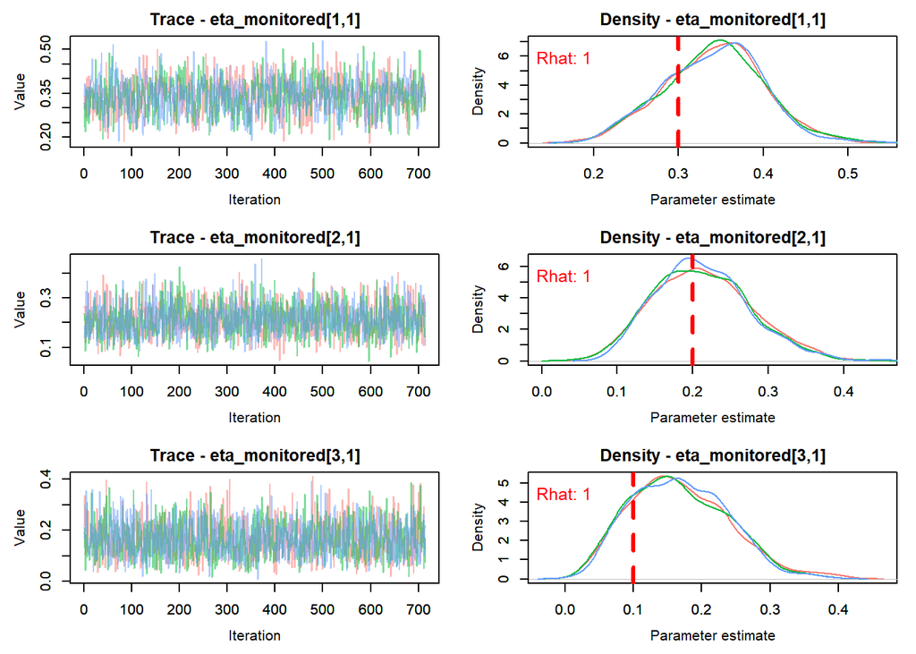

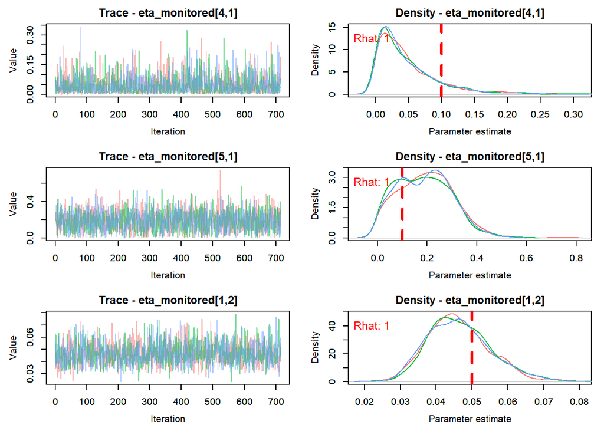

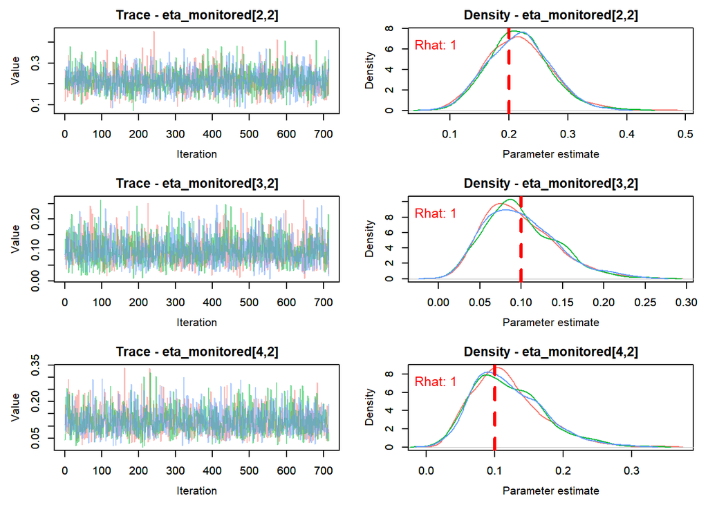

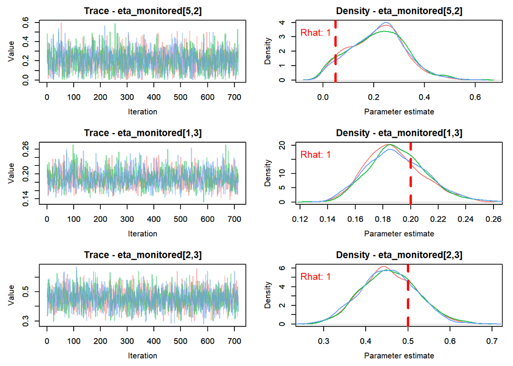

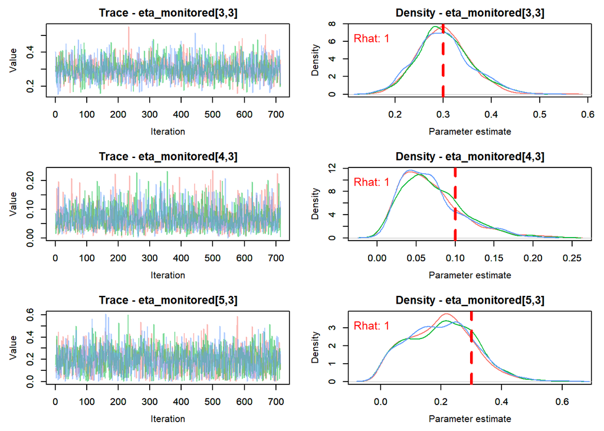

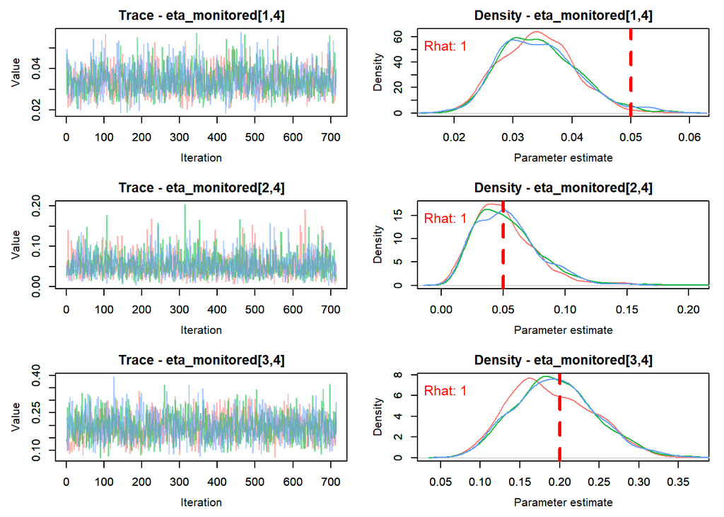

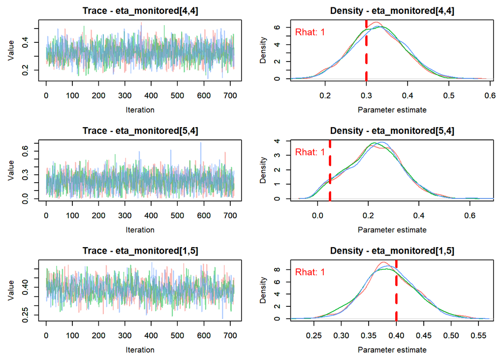

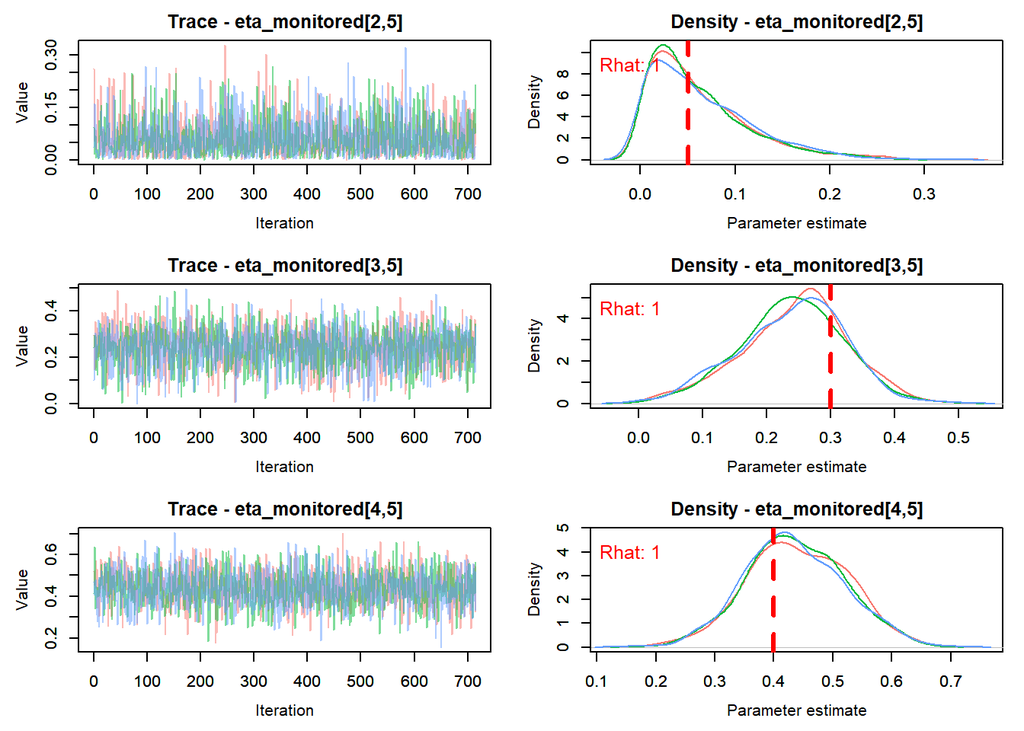

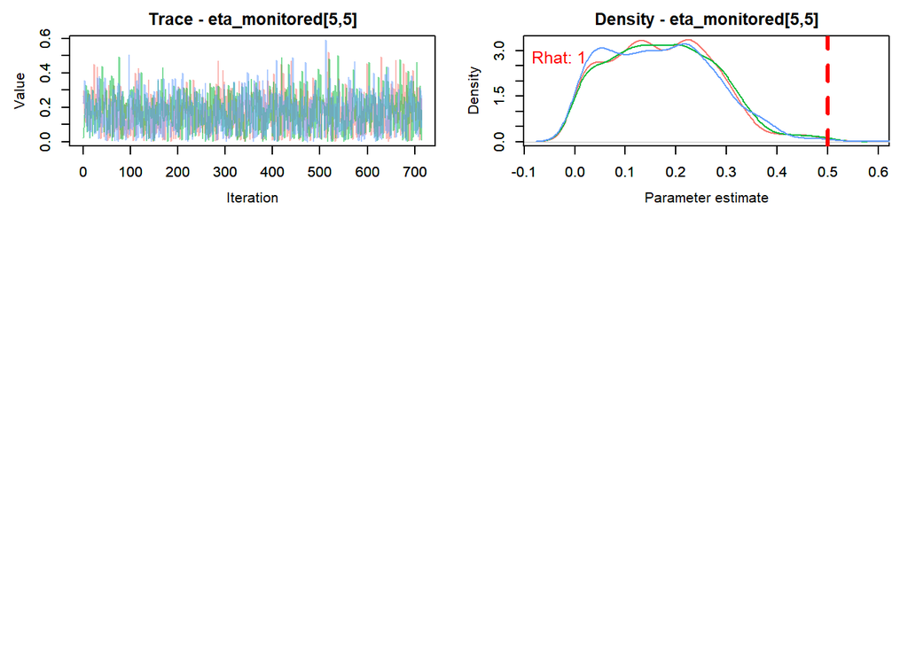

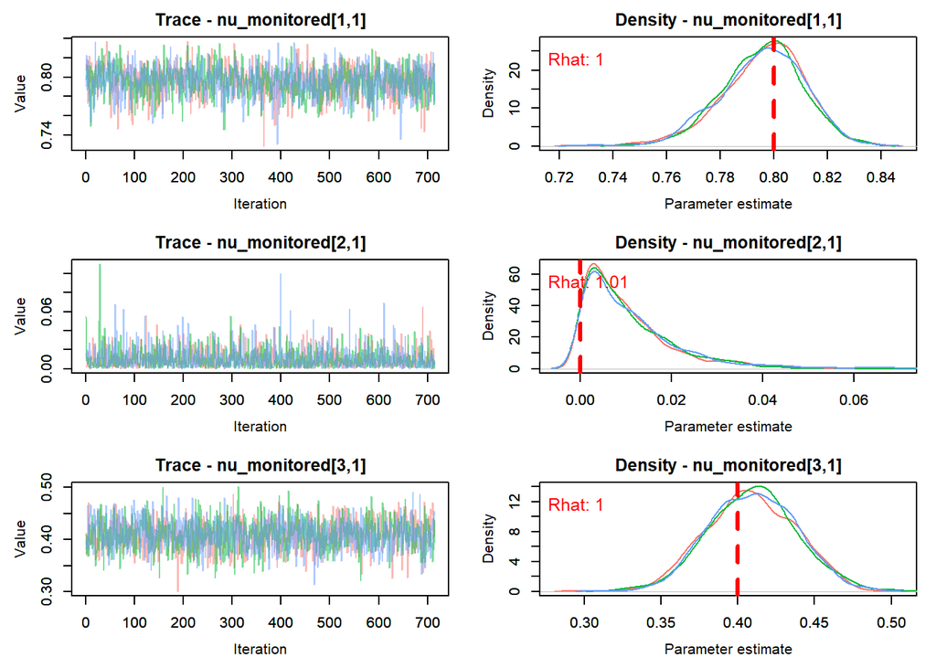

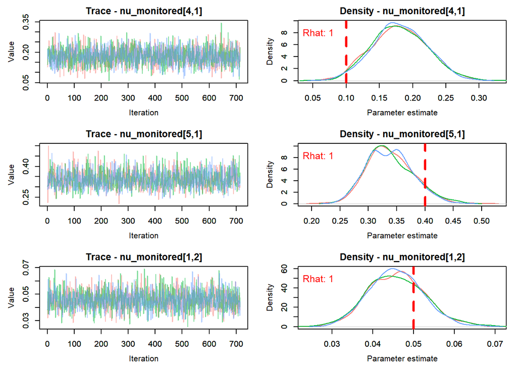

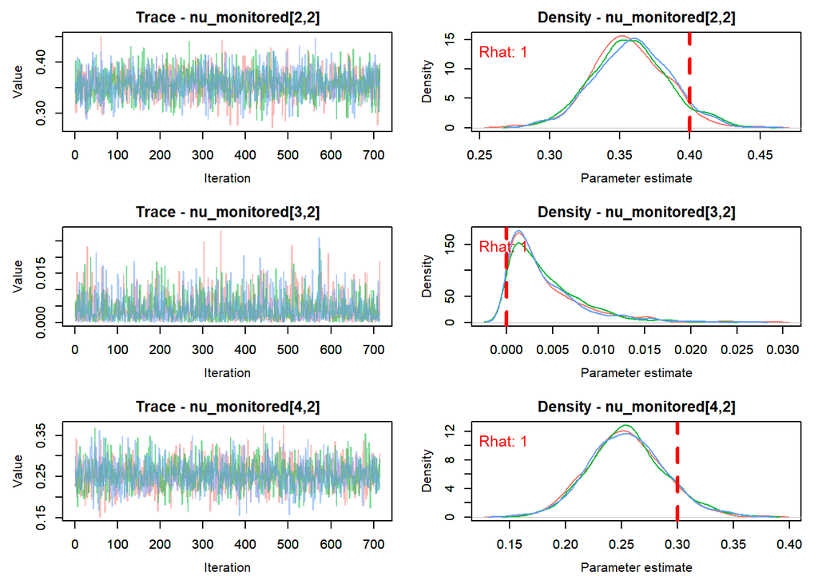

[6 more figures not shown]

# Recapture probability

In the simulation :

- time and colony dependence

p = matrix(runif(n = n.years*n.colony , min = 0.2, max = 0.4), nrow = n.years, ncol = n.colony)

In the analysis:

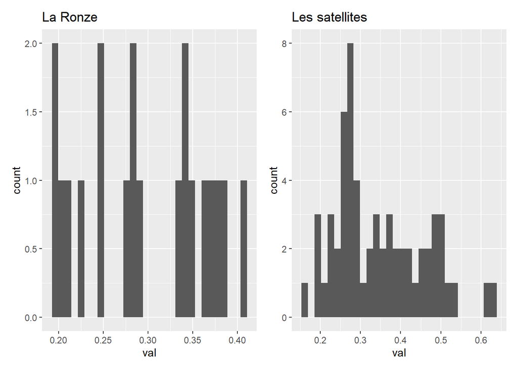

### Numbers of breeders and pre-breeders

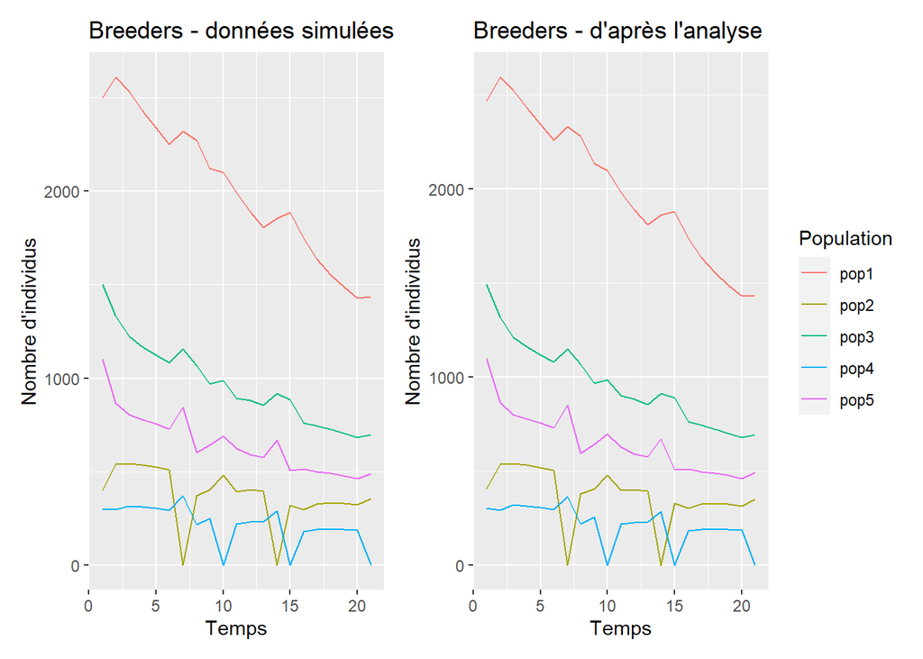

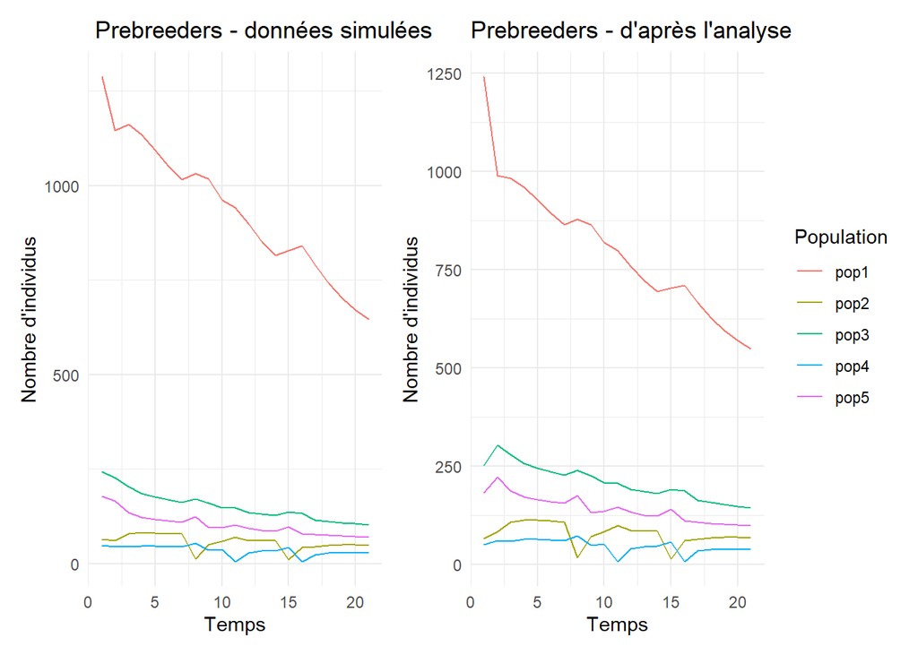